# Salary Tutorial

# Libraries

Not all of the functions are available in base `R`. So, we’ll have to load some extra functions in order to work with our data.

```r
library(corrplot)
library(skimr)
library(tidyverse)
```

If you cannot load these libraries with this code, then this means you haven’t installed those libraries. In `R`, you need to install libraries before you use them. To install a library, you use

```r
install.packages(c("tidverse", "skimr", "corrplot"), dep = TRUE)
```

# Load Data

There are important data on player salaries by whether they play on defense, offense, or special teams. Here, we load in all three datasets:

```r
df <- readRDS("../data/sportrac/defense.RDS")
of <- readRDS("../data/sportrac/offense.RDS")
st <- readRDS("../data/sportrac/special.RDS")
```

Note that depending on where your `R` script is located, you’ll have to change part of the code above so that it corresponds with how you’ve organized your files (i.e., you give the functions the correct paths).

Now we have three data frames, each with their own sets of variables.

The data were scraped from Sportrac, and contain players currently under contract, and some of the details of those players and contracts.

# Inspect Data

```r
head(of)
```

```
##             player start_yr end_yr pos team age yrs   dollars  average
## 1        Matt Ryan     2018   2023  QB  ATL  33   5 150000000 30000000
## 2  Jimmy Garoppolo     2018   2022  QB   SF  27   5 137500000 27500000
## 3 Matthew Stafford     2017   2022  QB  DET  31   5 135000000 27000000
## 4    Aaron Rodgers     2018   2023  QB   GB  35   4 134000000 33500000
## 5       Derek Carr     2017   2022  QB  OAK  27   5 125000000 25000000
## 6      Andrew Luck     2016   2021  QB  IND  29   5 122970000 24594000
##   guaranteed_at_signing practical_guarantees percent_gteed free_agent
## 1              94500000             1.00e+08         66.67       2024
## 2              41700000             7.41e+07         53.89       2023
## 3              60500000             9.20e+07         68.15       2023
## 4              79200000             9.87e+07         73.66       2024
## 5              40000000             7.02e+07         56.16       2023
## 6              44000000             8.70e+07         70.75       2022
```

Take some time to look through these rows and make sure you understand all of the variables in it.

## Summarizing the Data

The `skimr` library, which we loaded above, has a nice function `skim()` gives a nice ordered summary of your data, including univariate summary statistics and histograms:

```r
of %>% skim() %>% kable()
```

```
## Skim summary statistics
##  n obs: 780
##  n variables: 13
##
## Variable type: character
##
##  variable    missing    complete     n     min    max    empty    n_unique
## ----------  ---------  ----------  -----  -----  -----  -------  ----------
##    pos          0         780       780     1      2       0         9
##    team         0         780       780     2     15       0         56
##
## Variable type: factor
##
##  variable    missing    complete     n     n_unique       top_counts        ordered
## ----------  ---------  ----------  -----  ----------  -------------------  ---------
##   player        0         780       780      779       Isa: 2, A.J: 1, A     FALSE
##
## Variable type: integer
##
##   variable     missing    complete     n      mean       sd      p0     p25     p50     p75     p100      hist
## ------------  ---------  ----------  -----  ---------  ------  ------  ------  ------  ------  ------  ----------
##     age           0         780       780     25.44     3.54     0       23      25      27      41     ▁▁▁▁▇▅▁▁
##  free_agent       0         780       780    2020.89    0.98    2020    2020    2021    2021    2025    ▇▆▁▃▁▁▁▁
##
## Variable type: numeric
##
##        variable           missing    complete     n        mean           sd          p0        p25         p50          p75         p100        hist
## -----------------------  ---------  ----------  -----  ------------  ------------  --------  ---------  -----------  ------------  ---------  ----------
##         average              0         780       780    3212145.93    4847546.48    54000     570000     727526.5       4e+06       3.4e+07    ▇▁▁▁▁▁▁▁
##         dollars              0         780       780     1.2e+07       2.1e+07      108000    1115000    2701089.5     1.2e+07      1.5e+08    ▇▁▁▁▁▁▁▁
##         end_yr               0         780       780     2019.87         0.95        2019      2019        2020          2020        2024      ▇▆▁▃▁▁▁▁
##  guaranteed_at_signing       0         780       780    5292270.04      1e+07         0          0       272039.5     6525235.25    9.4e+07    ▇▁▁▁▁▁▁▁
##      percent_gteed           0         780       780      25.14         29.91         0          0         10.27        47.89         100      ▇▂▁▂▂▁▁▁
##  practical_guarantees        0         780       780    6530785.27     1.3e+07        0          0       275693.5     7518764.75     1e+08     ▇▁▁▁▁▁▁▁
##        start_yr              0         780       780     2017.64         1.13        2012      2017        2018          2018        2019      ▁▁▁▁▂▃▇▅
##           yrs                0         780       780       3.04          1.24         1          2           3            4            8       ▂▆▃▇▂▁▁▁
```

Note that in our syntax above, we used the pipe `%>%` command. This has the effect of saying take the object before the pipe (in this case, the `of` data frame) and feed it into the function after the pipe (`skim()`). You could get the same effect as the code above by running `skim(of)`.

While univariate summaries are important, we’re also interested in the relationship between variables. One way to examine that relationship is with the correlation between them. Correlation ranges between -1 and 1. Correlations close to -1 means that two variables are closely related, but that the larger one gets, the smaller the other gets. Correlations close to 0 means that the two variables are potentially unrelated. Correlations close to 1 means that to variables are closely related, and larger values of one variable are associated with larger values of the other.

We can get a plot of some important pairwise correlations in our data with the following code:

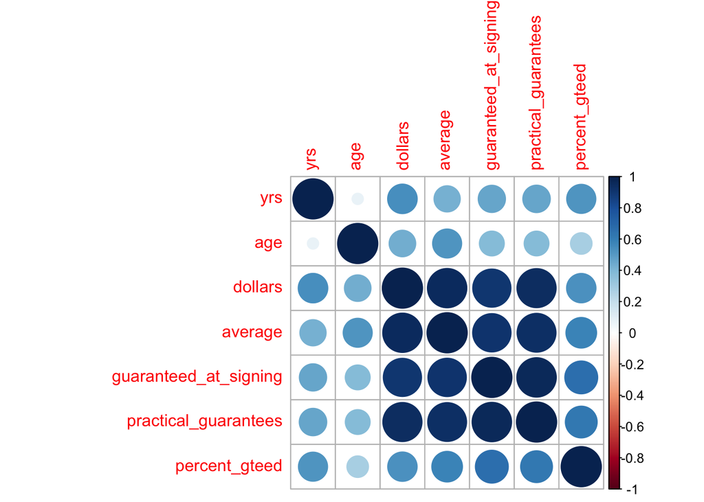

```r
of %>%
  select(yrs, age, dollars, average, guaranteed_at_signing, practical_guarantees, percent_gteed) %>%
  cor(.) %>%
  corrplot()
```

In this plot, we see that a player’s age is very weakly related to the length of their contract, but is more strongly related to the average salary. What else do you see in this plot?

## Other Visualization

Finally, not all relationships are captured by the correlation between variables. Particularly if relationships are not linear, sometimes the correlation between variables can be zero, even if they are closely related.

Thus, we might want to get other visualizations. To do that, we can use the `ggplot` library. This library treats your plot like a canvas. You start by saying what data you want to visualize, and then continually add layers to the plot. For example, in the code below, we say we want to visualize the offense data (first line), and that we want to add points corresponding to the average salary and percent guaranteed of the contract.

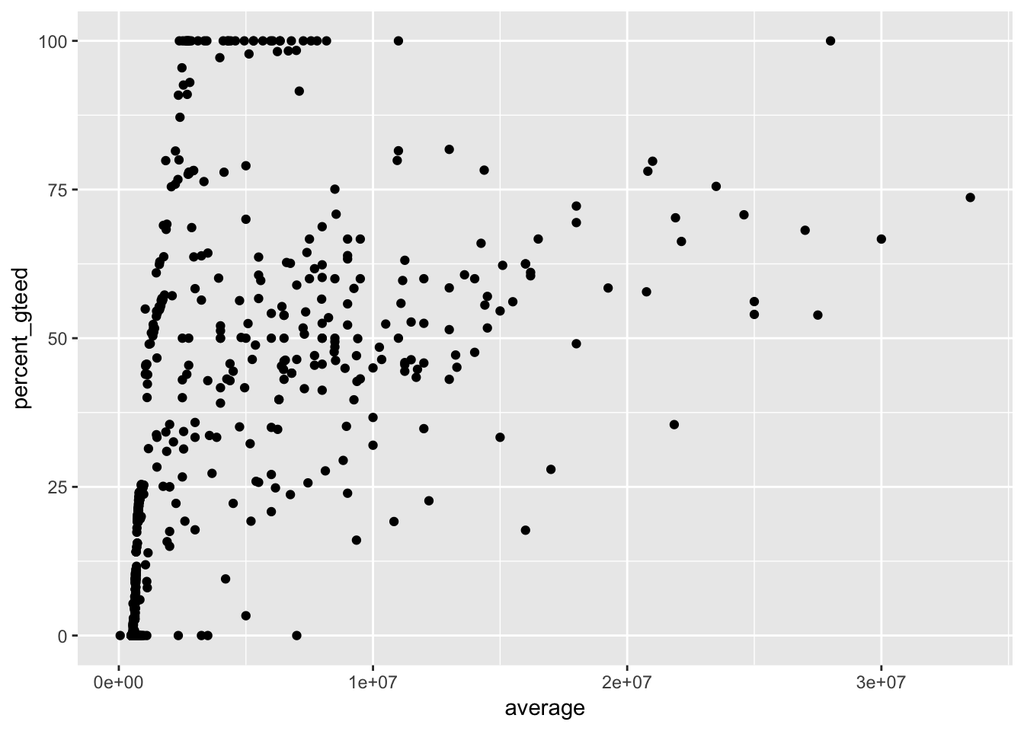

```r
ggplot(of) +
  geom_point(aes(average, percent_gteed)) # make sure the variable names are inside the aes() function
```

We might also be interested in differences in how much of the contract is guaranteed by position. Here we break this up into skill positions and linemen/fullbacks:

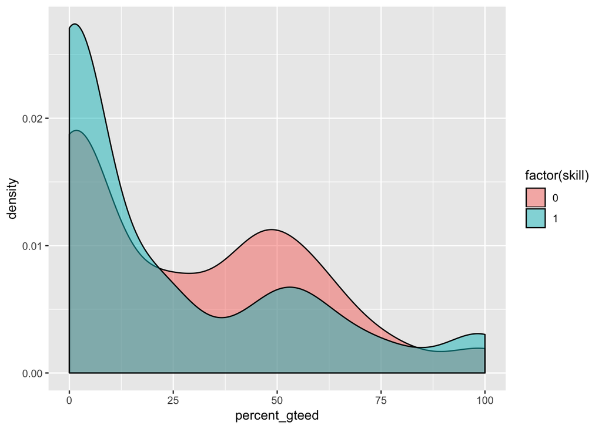

```r
of <- of %>%
  mutate(skill = ifelse(pos %in% c("QB", "RB", "TE", "WR"), 1, 0))

ggplot(of) +
  geom_density(aes(percent_gteed, fill = factor(skill)), alpha = 0.5)
```

Alternatively, we can look at stats within skill positions:

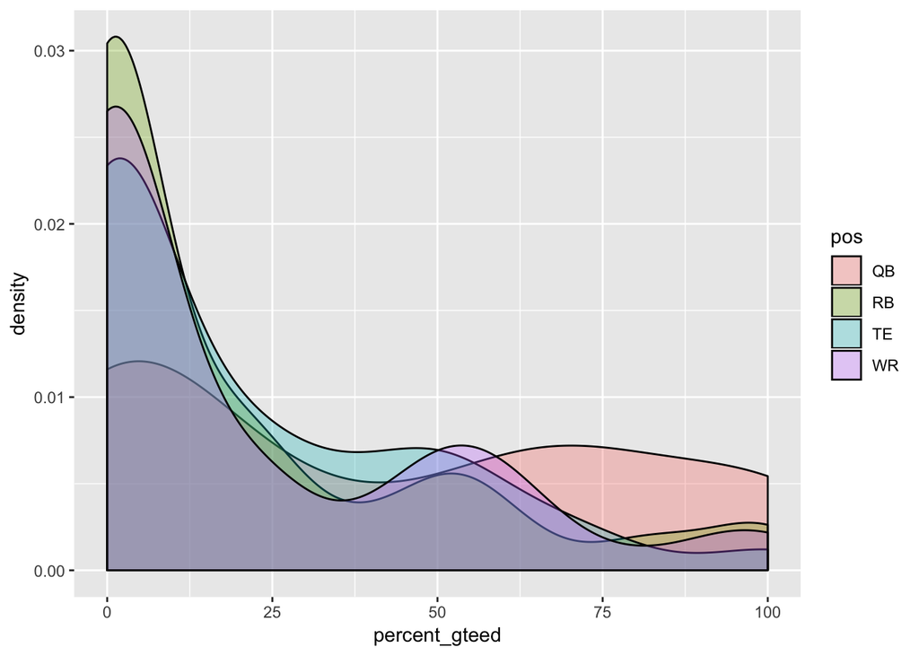

```r
of %>%
  filter(skill == 1) %>%
  ggplot() +
    geom_density(aes(percent_gteed, fill = pos), alpha = 0.3)
```

It looks like QBs tend to get more of their contracts guaranteed.

# Your Turn

Use the code above to do the following:

1. Create more visualizations for the offense dataset.
2. Repeat for the defense and special teams datasets.

Try to embed everything in Rmarkdown (i.e., the template document). We’ll look at how to add code chunks during the meeting.

If you get lost, a handy reference is the free e-book [R for Data Science](https://r4ds.had.co.nz/)

## Example

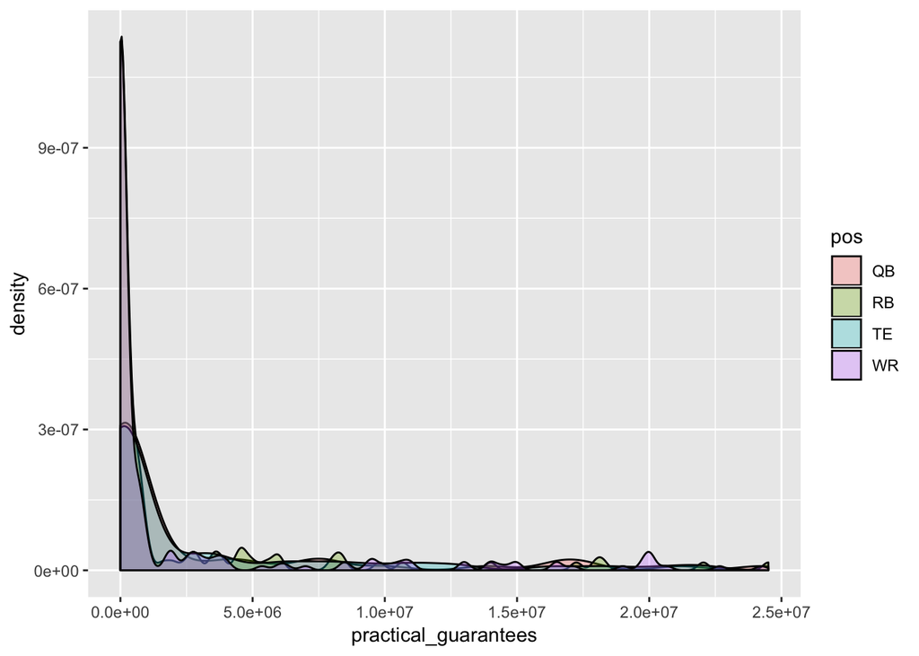

```r
of %>%
  filter(skill == 1,
         practical_guarantees < 2.5 * 10^7) %>%
  ggplot() +
    geom_density(aes(practical_guarantees, fill = pos), alpha = 0.3)
```

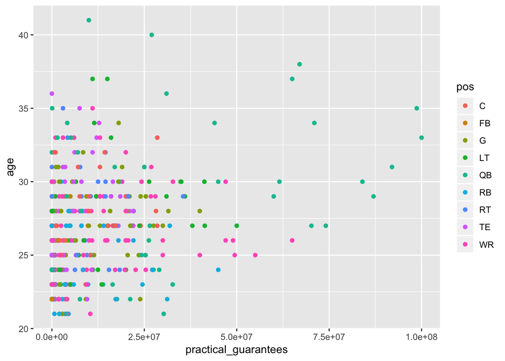

```r
of %>%
  filter(age > 0) %>%
  ggplot() +
    geom_point(aes(practical_guarantees, age, color = pos))
```